# Log Pots For All

Home

Audio circuits often use logarithmic and anti-log/reverse log potentiometers. Frequency and volume controls come to mind. Those kinds of tapers (especially the reverse log) are hard to find around here, and they aren’t even real log pots! They usually are a combination of two linear pots. See this excellent article by ESP [here](https://sound-au.com/project01.htm) for more info. In this same article, the author suggests the use of a linear pot with a loading resistor in order to approximate a log pot (more specifically, a volume pot). With this in mind, I set out to design a simple tool to help me calculate the adequate values. And while we’re at it, let’s do anti-log pots also!

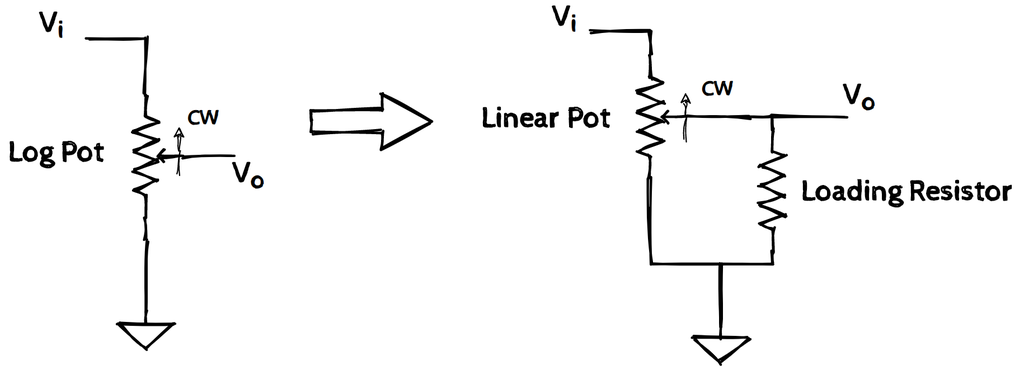

The log approximation

The log approximation is as described in the [article](https://sound-au.com/project01.htm). It is usually used as a volume control of sorts, so I tied one end to ground. In this way it is basically a resistive divider and, ignoring possible loadings to this circuit, the output is some fraction of the input. I could have presented this curve as a ratio between 0 and 1 (in this configuration the actual total resistance of the pot only matters when relating what impedances come before and after it). For the sake of clarity, I decided to multiply the ratio by the total resistance. As a reference, the aforementioned [article](https://sound-au.com/project01.htm) uses a ratio in DB to represent the Vout/Vin relation.

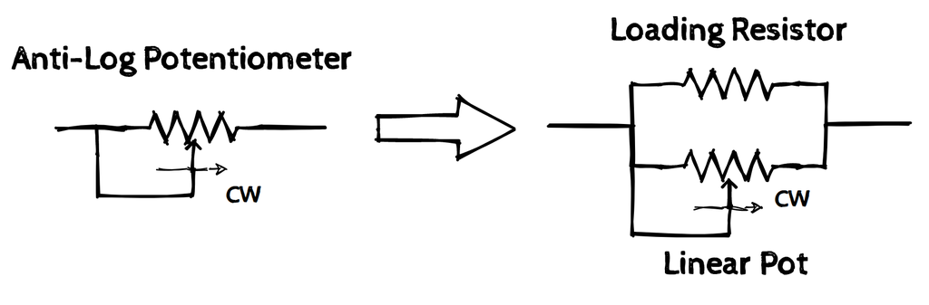

The anti-log approximation

The anti-log approximation is an actual variable resistor, and the results are really good!

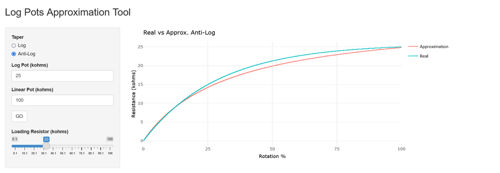

An anti-log example: the linear 100k pot in parallel with a 33k resistor make a very good aproximation of a 25k anti-log pot

While doing research for this project, I came across this great [post](http://benholmes.co.uk/posts/2017/11/logarithmic-potentiometer-laws) by Ben Holmes that presents a model for logarithmic pots. Not trying to reinvent the wheel, I used his derivation of the model and chose the 50% rotation travel to represent 15% and 85% of the resistances for the log and anti-log pots respectively.

The live version can be used [here](https://thomas-jagoda.shinyapps.io/log-pot/). You can also check it on [Github](https://github.com/JagodaT/log-pots).